# Part II - Explanatory Analysis

## Investigation Overview

This notebook aims to translate the exploratory findings into a concise narrative that answers: How do borrower characteristics and loan features on Prosper influence loan outcomes and interest rates?

## Dataset Overview and Executive Summary

We analyzed 113,937 Prosper loan records with 81 features. Key fields used:

- LoanOriginalAmount (loan size)
- BorrowerRate (interest rate)
- StatedMonthlyIncome (income)
- ProsperRating (Alpha) (credit grade)
- Term (loan duration)
- LoanStatus (loan outcome)
- Below are three polished visualizations that illustrate these insights.

```python
# import all packages and set plots to be embedded inline
import numpy as np
import pandas as pd
import matplotlib.pyplot as plt
import seaborn as sns

# suppress warnings from final output
import warnings
warnings.simplefilter("ignore")
```

```python
# load dataset
df = pd.read_csv('prosperLoanData.csv')
sns.set_style('whitegrid')
```

## Visualization 1: Loan Amount Distribution

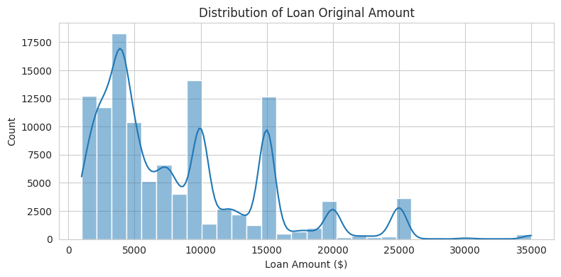

```python
plt.figure(figsize=(8,4))
sns.histplot(df['LoanOriginalAmount'], bins=30, kde=True)
plt.title('Distribution of Loan Original Amount')
plt.xlabel('Loan Amount ($)')
plt.ylabel('Count')
plt.tight_layout()
plt.show()
```

**Comment:** The distribution is right‑skewed, with most loans below $10,000 and a long tail of larger loans.

## Visualization 2: Income vs. Interest Rate

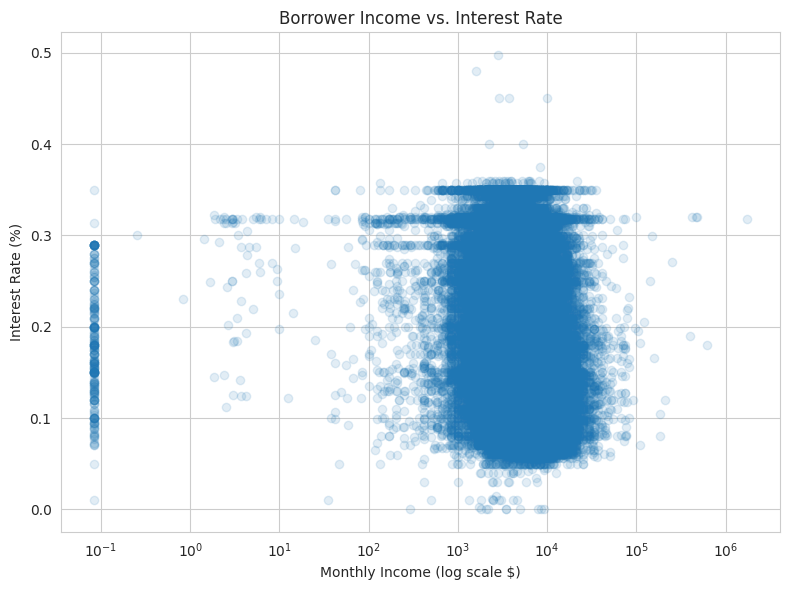

```python
plt.figure(figsize=(8,6))
plt.scatter(df['StatedMonthlyIncome'], df['BorrowerRate'], alpha=1/8)
plt.xscale('log')
plt.title('Borrower Income vs. Interest Rate')
plt.xlabel('Monthly Income (log scale $)')
plt.ylabel('Interest Rate (%)')
plt.tight_layout()
plt.show()
```

**Comment**: A weak negative trend indicates that higher incomes are associated with slightly lower interest rates, supporting targeted income verification.

## Visualization 3: Credit Grade vs. Borrower Rate

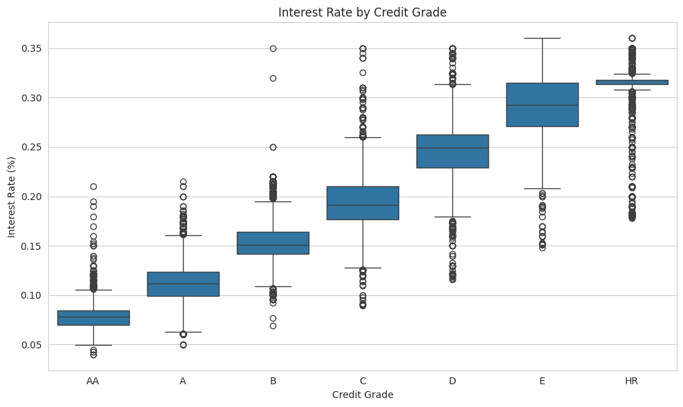

```python
plt.figure(figsize=(10,6))
sns.boxplot(
    x='ProsperRating (Alpha)', y='BorrowerRate', data=df,
    order=['AA','A','B','C','D','E','HR']
)
plt.title('Interest Rate by Credit Grade')
plt.xlabel('Credit Grade')
plt.ylabel('Interest Rate (%)')
plt.tight_layout()
plt.show()
```

**Comment:** AA and A grades have the lowest median rates, while HR has the highest.